# DA_hw06

Lin,Pei Chen

2023-04-03

Q1. (a)

```r
PCA <- function(x,isCorrMX=FALSE){
  x<-as.matrix(x)
  n<-nrow(x)
  means<-colMeans(x[1:nrow(x),1:ncol(x)])
  mean<-c()
  for(i in 1:ncol(x)){
    mean<-cbind(mean,rep(means[i],nrow(x)))
  }
  A<-as.matrix(x-mean)
  cov<-t(A)%*%A/(n-1)
  sigma<-c()
  for(i in 1:ncol(x)){
    sigma<-cbind(sigma,rep(sqrt(diag(cov)[i]),nrow(x)))
  }
  y<-A/sigma
  corr<-(t(y)%*%y)/(n-1)
  if(isCorrMX==FALSE){
    eigen<-eigen(cov)
  }
  else{
    eigen<-eigen(corr)
  }
  lambda<-eigen$values
  P<-eigen$vectors
  T<-x%*%P
  total_variance<-data.frame(PCA=character(),variance=numeric(),contribution=numeric(),cumulative=numeric())
  cum<-0
  colnames<-c()
  for(i in 1:ncol(x)){
    pc<-lambda[i]/sum(lambda)
    PCA_name <- paste("PC", i, sep = "")
    cum<-cum+pc
    total_variance[i,]<-c(PCA_name,lambda[i],pc,cum)
    colnames<-cbind(colnames,PCA_name)
  }
  total_variance[, c("variance", "contribution", "cumulative")] <- sapply(total_variance[, c("variance", "contribution", "cumulative")], as.numeric)
  colnames(P)<-c(colnames)
  rownames(P)<-colnames(x)
  n_labels<-length(colnames)
  if(n_labels<=10){
    limit_labels <-colnames
  }else{
    limit_labels<-colnames[1:10]
  }
  library(ggplot2)
  plot<-ggplot(total_variance, aes(x = PCA)) +
    geom_col(aes(y = variance/max(total_variance[["variance"]])), fill = "steelblue") +
    geom_line(aes(y = cumulative,group = 1), color = "indianred3",size=0.6)+
    geom_point(aes(y=cumulative,group = 1),size=3,shape=21,fill="indianred3") +
    scale_y_continuous(
      breaks = seq(0, 1, 0.1),
      labels = paste0(seq(0, 100, 10), "%"),
      name = "Cumulative Percentage",
      sec.axis = sec_axis(~.*max(total_variance[["variance"]]) , name = "Variance")
    ) +
    labs(x = "Principal Component") +
    scale_x_discrete(limits=limit_labels)+
    theme_bw()
  return(list(loadingMatrix=P,eigenvalue=lambda,score_matrix=T,scree_plot=plot,total_variance=total_variance))
}
FA<-function(x,nfactors){
  x<-as.matrix(x)
  results<-PCA(x,isCorrMX = TRUE)
  n<-nrow(x)
  means<-colMeans(x[1:nrow(x),1:ncol(x)])
  mean<-c()
  for(i in 1:ncol(x)){
    mean<-cbind(mean,rep(means[i],nrow(x)))
  }
  A<-as.matrix(x-mean)
  cov<-t(A)%*%A/(n-1)
  sigma<-c()
  for(i in 1:ncol(x)){
    sigma<-cbind(sigma,rep(sqrt(diag(cov)[i]),nrow(x)))
  }
  y<-A/sigma
  corr<-(t(y)%*%y)/(n-1)
  eigenvector<-c()
  eigenvalue<-c()
  for(i in 1:nfactors){
    eigenvector<-cbind(eigenvector,results$loadingMatrix[,i])
    eigenvalue<-rbind(eigenvalue,results$eigenvalue[i])
  }
  sqrt_eigenvalue<-diag(0,nfactors)
  for(i in 1:nfactors){
    sqrt_eigenvalue[i,i]<-sqrt(eigenvalue)[i]
  }
  A_t<-eigenvector%*%sqrt_eigenvalue
  psi<-diag(0,nrow(corr))
  z<-A_t%*%t(A_t)
  corr_z<-corr-z
  for(i in 1:nrow(corr)){
    psi[i,i]<-corr_z[i,i]
  }
  total_variance<-ncol(x)
  communality<-c()
  for(i in 1:nrow(corr)){
    communality<-rbind(communality,corr[i,i]-psi[i,i])
  }
  F<- x%*%solve(psi)%*%A_t%*%solve(t(A_t)%*%solve(psi)%*%A_t)
  proportion<-data.frame(contribution=numeric())
  for(i in 1:nfactors){
    pc<-eigenvalue[i]/total_variance
    proportion[i,]<-c(pc)
  }
  return(list(loadingMatrix=A_t,factorMatrix=F,communality=communality,psi=psi,proportion=proportion))
}
```

```r
setwd("C:/Users/simpl/OneDrive/桌面/111_下學期/資料分析方法/HW03")
data <- read.table("auto-mpg.data.txt",header = FALSE,sep = "")
str(data)
```

```
## 'data.frame':    398 obs. of  9 variables:
##  $ V1: num  18 15 18 16 17 15 14 14 14 15 ...
##  $ V2: int  8 8 8 8 8 8 8 8 8 8 ...
##  $ V3: num  307 350 318 304 302 429 454 440 455 390 ...
##  $ V4: chr  "130.0" "165.0" "150.0" "150.0" ...
##  $ V5: num  3504 3693 3436 3433 3449 ...
##  $ V6: num  12 11.5 11 12 10.5 10 9 8.5 10 8.5 ...
##  $ V7: int  70 70 70 70 70 70 70 70 70 70 ...
##  $ V8: int  1 1 1 1 1 1 1 1 1 1 ...
##  $ V9: chr  "chevrolet chevelle malibu" "buick skylark 320" "plymouth satellite" "amc rebel sst" ...
```

```r
colnames(data) <- c("mpg","cylinders","displacement","horsepower","weight","acceleration","model_year","origin","car name")

data_withoutcarname<-subset(data,select=c(1:(ncol(data)-1)))
data_withoutcarname$horsepower<- as.numeric(data_withoutcarname$horsepower)
x<-na.omit(data_withoutcarname)
FA(x,2)
```

```
## $loadingMatrix
##                    [,1]        [,2]
## mpg           0.8946577 -0.07444278
## cylinders    -0.9329751 -0.13447295
## displacement -0.9655648 -0.12271505
## horsepower   -0.9316939  0.10829434
## weight       -0.9310907 -0.20498974
## acceleration  0.6138031 -0.40498838
## model_year    0.4958723 -0.67073205
## origin        0.6442631  0.48716942
##
## $factorMatrix
##           [,1]       [,2]
## 1    -737.0378 -1700.4293
## 2    -792.1121 -1783.8810
```

[output cut: 426 more lines]

```r
y<-FA(x,2)
library(ggrepel)
```

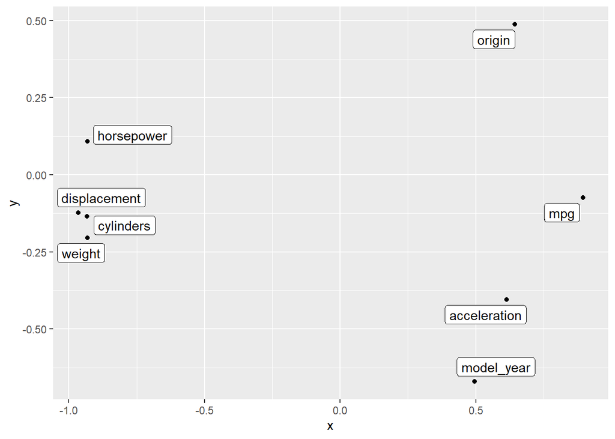

```r
mydata<-data.frame(x=y$loadingMatrix[,1],
                   y=y$loadingMatrix[,2],
                   label=c("mpg","cylinders","displacement","horsepower","weight","acceleration","model_year","origin"))
ggplot(mydata, aes(x = x, y = y,label=label)) +
  geom_point()+
  geom_label_repel()
```

```r
pca<-PCA(x,TRUE)
pca$loadingMatrix
```

```
##                     PC1         PC2           PC3         PC4         PC5
## mpg           0.3858624 -0.07663269 -0.2922857863  0.09998251  0.74036644
## cylinders    -0.4023885 -0.13842878 -0.0722393515 -0.21603551  0.48261485
## displacement -0.4164443 -0.12632499 -0.0742362247 -0.13581398  0.30331627
## horsepower   -0.4018359  0.11148007 -0.2360557124 -0.11971643 -0.08426839
## weight       -0.4015758 -0.21102000  0.0008939861 -0.32246785 -0.13127292
## acceleration  0.2647309 -0.41690206  0.6394351361 -0.49280794  0.09773197
## model_year    0.2138678 -0.69046320 -0.5871891991 -0.10601968 -0.30134385
## origin        0.2778682  0.50150064 -0.3073238207 -0.74328281 -0.04739508
##                       PC6         PC7         PC8
## mpg           0.387351653 -0.19588516 -0.11513210
## cylinders    -0.530925481  0.27878265 -0.41774679
## displacement -0.006997047 -0.08422855  0.82916553
## horsepower    0.666709602  0.53504996 -0.13477548
## weight        0.235859612 -0.72202073 -0.30991105
## acceleration  0.202933431  0.22891382  0.03518826
## model_year   -0.110025917  0.12501506  0.05428840
## origin       -0.120866629 -0.03452660  0.07951102
```

The above plot shows that the mpg data may have two latent groups. One group contains the variables “horsepower”,“displacement”,“cylinders”,“weight”. The another group contains the variable “origin”,“acceleration”,“model_year”. As we seen the meaning of the variables, we can make this conclusion that The first group is associate with the engine and the other group is associate with the information of individual car model.

We can see the results of PCA, the PC1 generate the similar results with FA. But the meaning of two analysis is different. One is maximum the variance of variables and the other is find the latent variables in a data set.

Q2.

```r
library(png)
library(dplyr)
library(scales)
library(reshape2)
path <- "C:/Users/simpl/OneDrive/桌面/111_下學期/資料分析方法/HW02/ORL Faces/ORL Faces"

data <- data.frame(matrix(nrow = 0, ncol = 2576),row.names = character())

for (i in 1:40) {
  for(j in 1:10){
    file <- file.path(path, paste0( i,"_",j,".png"))
    img <- readPNG(file)
    vec <- as.vector(img)
    data <- rbind(data, vec)
  }
}
names(data) <- paste0("Pixel", 1:2576)
results<-FA(data,100)
factor_count<-data.frame(tv=c("50%","60%","70%","80%","90%"),
                            count=0)
j<-1
z<-0.5
cum<-0
for(i in 1:100){
  cum<-cum+results$proportion[i,]
  if(cum>=z){
    factor_count[j,2]<-i
    j<- j+1
    z<-z+0.1
  }
  if(j==6){
    break
  }
}
factor_count
```

```
##    tv count
## 1 50%     6
## 2 60%     9
## 3 70%    17
## 4 80%    34
## 5 90%    79
```

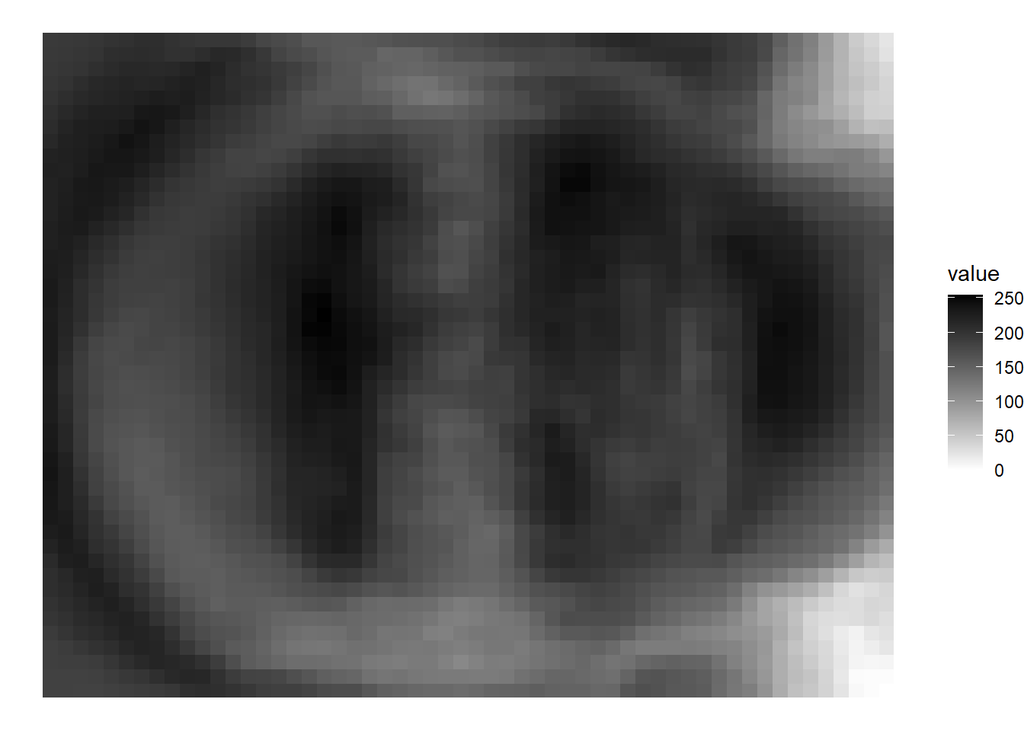

```r
results<-FA(data,35)
firstF<-results$loadingMatrix[,1]
f1_rescaled<-rescale(firstF, to=c(0,255))
f1_matrix<-matrix(f1_rescaled,nrow = 56,ncol=46)
df<-melt(f1_matrix)
ggplot(df, aes(Var1, Var2)) +
  geom_raster(aes(fill=value))+
  scale_fill_gradient(low = "white", high = "black") +
  theme_void()
```

Q3.

```r
library(pls)
set.seed(999)
setwd("C:/Users/simpl/OneDrive/桌面/111_下學期/資料分析方法/HW03")
data <- read.table("auto-mpg.data.txt",header = FALSE,sep = "")
str(data)
```

```
## 'data.frame':    398 obs. of  9 variables:
##  $ V1: num  18 15 18 16 17 15 14 14 14 15 ...
##  $ V2: int  8 8 8 8 8 8 8 8 8 8 ...
##  $ V3: num  307 350 318 304 302 429 454 440 455 390 ...
##  $ V4: chr  "130.0" "165.0" "150.0" "150.0" ...
##  $ V5: num  3504 3693 3436 3433 3449 ...
##  $ V6: num  12 11.5 11 12 10.5 10 9 8.5 10 8.5 ...
##  $ V7: int  70 70 70 70 70 70 70 70 70 70 ...
##  $ V8: int  1 1 1 1 1 1 1 1 1 1 ...
##  $ V9: chr  "chevrolet chevelle malibu" "buick skylark 320" "plymouth satellite" "amc rebel sst" ...
```

```r
colnames(data) <- c("mpg","cylinders","displacement","horsepower","weight","acceleration","model_year","origin","car name")

data_withoutcarname<-subset(data,select=c(1:(ncol(data)-1)))
data_withoutcarname$horsepower<- as.numeric(data_withoutcarname$horsepower)
```

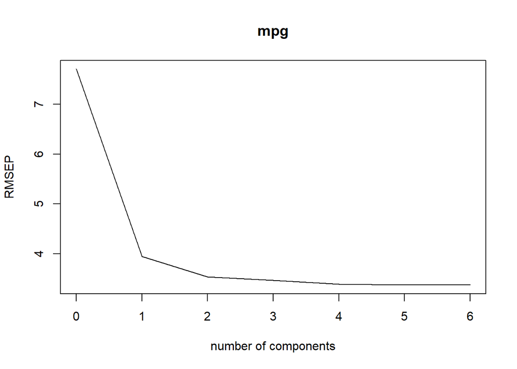

```r
x<-na.omit(data_withoutcarname)

select_cars<-sample(nrow(x),300)
training_data<-x[select_cars,]
test_data<-x[-select_cars,]

X_train_matrix<-as.matrix(training_data[2:7])
Y_train_matrix<-as.matrix(training_data[1])

X_test_matrix<-as.matrix(test_data[2:7])
Y_test_matrix<-as.matrix(test_data[1])
model<-plsr(Y_train_matrix~X_train_matrix,scale=TRUE)
plot(RMSEP(model),main="mpg")
```

The above plot shows that the more components the lower RMSE so we use the six components to model and predict the testing data.

```r
RMSEP(model)
```

```
## (Intercept)      1 comps      2 comps      3 comps      4 comps      5 comps
##       7.709        3.941        3.538        3.466        3.387        3.372
##     6 comps
##       3.371
```

```r
test_predictions<-as.matrix(data.frame(predict(model,ncomp=6,X_test_matrix)))
mean_r2 <- mean(diag(cor(test_predictions, Y_test_matrix))**2)
print(mean_r2)
```

```
## [1] 0.8061601
```

The R square is 0.8061. This model shows great explanatory power.

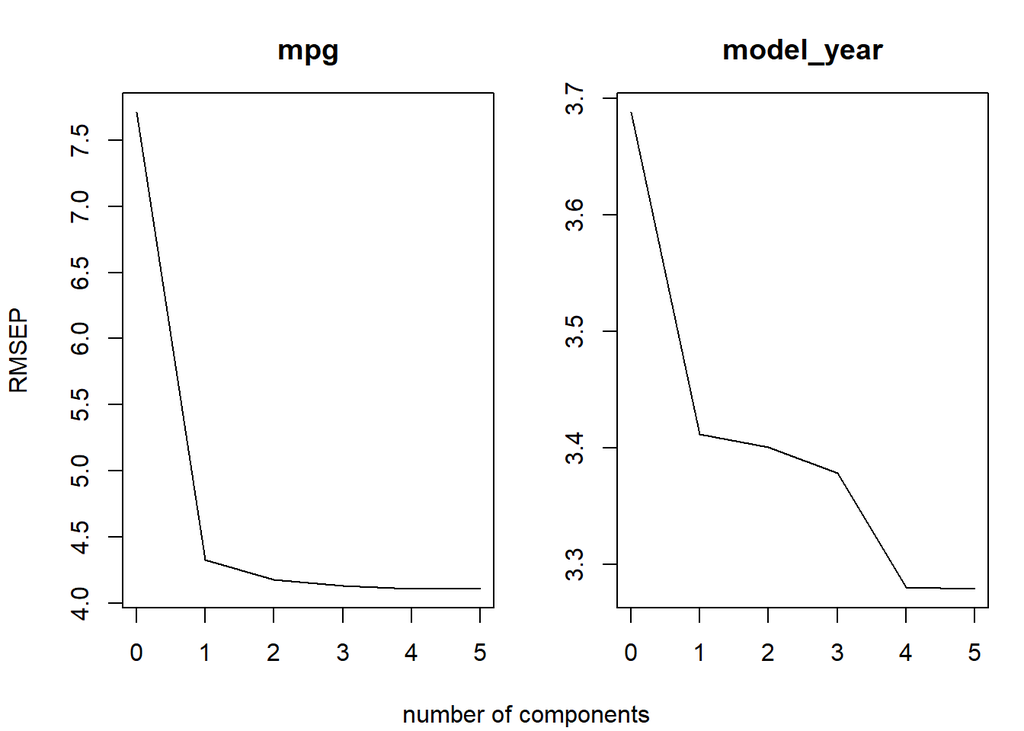

```r
X_train_matrix<-as.matrix(training_data[2:6])
Y_train_matrix<-as.matrix(training_data[c(1,7)])

X_test_matrix<-as.matrix(test_data[2:6])
Y_test_matrix<-as.matrix(test_data[c(1,7)])
model2<-plsr(Y_train_matrix~X_train_matrix,scale=TRUE)
plot(RMSEP(model2))
```

```r
RMSEP(model2)
```

```
##
## Response: mpg
## (Intercept)      1 comps      2 comps      3 comps      4 comps      5 comps
##       7.709        4.331        4.181        4.130        4.109        4.109
##
## Response: model_year
## (Intercept)      1 comps      2 comps      3 comps      4 comps      5 comps
##       3.688        3.412        3.400        3.378        3.280        3.279
```

```r
test_predictions <- as.matrix(data.frame(predict(model2, ncomp=5, X_test_matrix)))
mean_r2 <- mean(diag(cor(test_predictions, Y_test_matrix))**2)
print(mean_r2)
```

```
## [1] 0.413965
```